# Untitled-1 (1)

```python
import pandas as pd, numpy as np
import matplotlib.pyplot as plt
import seaborn as sns
import statsmodels.tsa.stattools as smt
from itertools import combinations,permutations
from statsmodels.tsa.stattools import adfuller
from matplotlib.pylab import rcParams
rcParams['figure.figsize'] = 10, 6
import statsmodels.api as sm
from statsmodels.tsa.seasonal import seasonal_decompose
from statsmodels.tsa.stattools import acf, pacf
from statsmodels.tsa.arima.model import ARIMA
from statsmodels.tsa.stattools import arma_order_select_ic
from statsmodels.graphics.tsaplots import plot_acf, plot_pacf
```

```python
#sp_0 = pd.read_csv(r"C:\Users\Iago Vale\Desktop\LESTAT\SP_0.csv")
sp_1 = pd.read_csv(r"C:\Users\julia\Downloads\SP_1.csv")
```

```python
sp_1['date_time'] =  sp_1[['date_time']].apply(pd.to_datetime)
```

```python
sp_1.info()
```

```
<class 'pandas.core.frame.DataFrame'>
RangeIndex: 88440 entries, 0 to 88439
Data columns (total 49 columns):
 #   Column                                                        Non-Null Count  Dtype
---  ------                                                        --------------  -----
 0   date_time                                                     88440 non-null  datetime64[ns]
 1   A701 - precipitacao total, horario (mm)                       88440 non-null  float64
 2   A701 - pressao atmosferica ao nivel da estacao, horaria (mb)  88440 non-null  float64
 3   A701 - pressao atmosferica max. na hora ant. (aut) (mb)       88440 non-null  float64
 4   A701 - pressao atmosferica min. na hora ant. (aut) (mb)       88440 non-null  float64
 5   A701 - temperatura do ar - bulbo seco, horaria (°c)           88440 non-null  float64
 6   A701 - temperatura do ponto de orvalho (°c)                   88440 non-null  float64
 7   A701 - temperatura maxima na hora ant. (aut) (°c)             88440 non-null  float64
 8   A701 - temperatura minima na hora ant. (aut) (°c)             88440 non-null  float64
 9   A701 - temperatura orvalho max. na hora ant. (aut) (°c)       88440 non-null  float64
```

[output cut: 41 more lines]

Nessa etapa o dataset é filtrado para a estação $A701$ que corresponde a estação de Mirante em São Paulo. Ele se inicia no dia 30 de março de 2011 e vai até o dia 30 de abril de 2021. Além disso, as variáveis estudadas para o presente trabalho serão: Data, Média da Precipitação total diária, Média da Pressão atmosférica diária, Média da Temperatura do ar diária, Média da Umidade relativa do ar diária, Média da velocidade do vento diária.

```python
sp_1 = sp_1[['date_time',  'A701 - precipitacao total, horario (mm)', 'A701 - pressao atmosferica ao nivel da estacao, horaria (mb)',
        'A701 - temperatura do ar - bulbo seco, horaria (°c)', 'A701 - umidade relativa do ar, horaria (%)',
        'A701 - vento velocidade horaria (m/s)']]
```

Os dados estavam dividos em horas, por isso, colocamos eles pra dias. Para facilitar nas interpretações e no processamento da máquina.

```python
sp_1['dates'] = sp_1['date_time'].dt.date
grouped_dates = sp_1.groupby('dates').mean()
grouped_dates = grouped_dates.reset_index()
```

```python
grouped_dates_filtrado = grouped_dates.reset_index()
#grouped_dates_filtrado.drop(columns= ['dates', 'date_time', 'index', 'level_0'], inplace = True)
```

## Análise descritiva

Segundo Deborah J. Rumsey, autora do livro 'Estatística para Dummies', para que consigamos entender a natureza dos dados e identificar padrões ou tendências interessantes, antes de prosseguir com análises mais complexas, será feita uma análise descritiva. Sendo ela definida como um tipo de análise estatística que visa resumir e descrever de maneira objetiva as principais características de um conjunto de dados. Iniciando com a utilizalção do $.describe()$ e considerando que os valores foram ajustados para a média conseguimos observar o seguinte comportamento:

```python
grouped_dates_filtrado.describe()
```

|  | index | A701 - precipitacao total, horario (mm) | A701 - pressao atmosferica ao nivel da estacao, horaria (mb) | A701 - temperatura do ar - bulbo seco, horaria (°c) | A701 - umidade relativa do ar, horaria (%) | A701 - vento velocidade horaria (m/s) |
| --- | --- | --- | --- | --- | --- | --- |
| count | 3685.000000 | 3685.000000 | 3685.000000 | 3685.000000 | 3685.000000 | 3685.000000 |
| mean | 1842.000000 | 0.174803 | 927.260179 | 20.506637 | 69.450565 | 1.878184 |
| std | 1063.912199 | 0.452284 | 3.378949 | 3.368058 | 10.732465 | 0.694331 |
| min | 0.000000 | 0.000000 | 917.804167 | 7.112500 | 26.333333 | 0.000000 |
| 25% | 921.000000 | 0.000000 | 924.929167 | 18.283333 | 63.666667 | 1.420833 |
| 50% | 1842.000000 | 0.000000 | 927.008333 | 20.687500 | 70.458333 | 1.858333 |
| 75% | 2763.000000 | 0.091667 | 929.425000 | 22.912500 | 76.500000 | 2.308333 |
| max | 3684.000000 | 5.958333 | 938.875000 | 30.983333 | 98.250000 | 4.837500 |

Passando pelo mapa de correlação, de acordo com a mesma autora, um mapa de correlação é uma representação visual de como duas ou mais variáveis quantitativas estão relacionadas entre si. Ele mostra a magnitude e a direção da correlação entre as variáveis, ou seja, se elas variam juntas ou em direções opostas, e em que medida. Os valores de correlação são geralmente exibidos em uma matriz, na qual as células da diagonal principal representam a auto-correlação de uma variável consigo mesma e as demais células mostram a correlação entre duas variáveis diferentes.

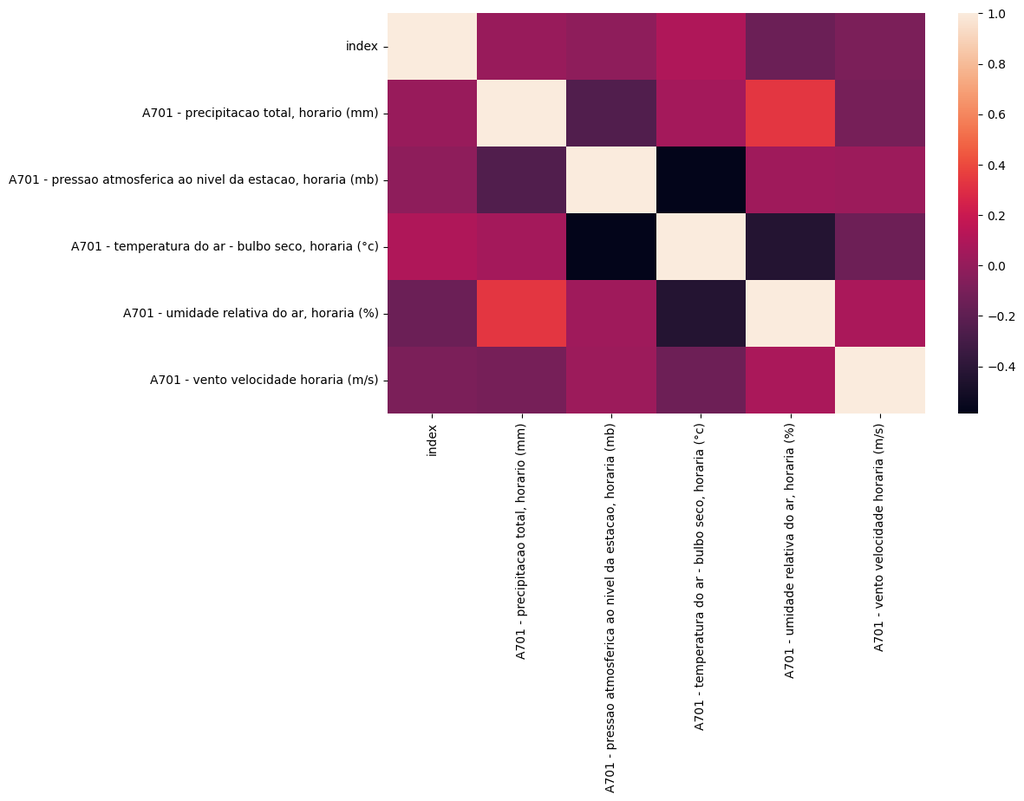

```python
mapa_de_correlacao = sns.heatmap(grouped_dates_filtrado.corr())
```

Na próxima representação, buscamos representar o comportamento da variável ao longo do tempo. Com isso, obtivemos o seguinte *output*:

- Precipitação total em milimetros

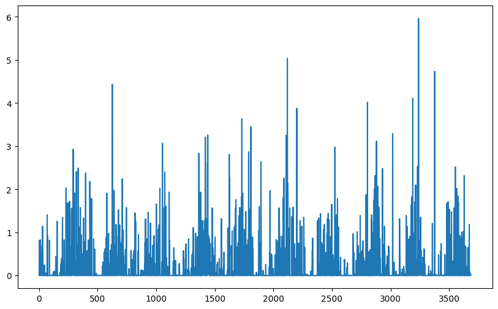

```python
plt.plot(grouped_dates['A701 - precipitacao total, horario (mm)'])
```

Nesse caso registramos a quantidade de milimetros de chuva por dia na região de Mirante em São Paulo, onde a gente consegue perceber um comportamento cíclio ao longo dos anos onde temos chuvas torrenciais, ou seja, quando chove bastante num período curto de tempo sobre uma área pequena. Segundo o site Clima Tempo, uma forte hipótese é que essas chuvas tenham acontecido no período de Dezembro à Março, pois esse é o período do ano onde há mais chuvas no estado de São Paulo e principalmente em Mirante.

- Pressão atmosférica em mb

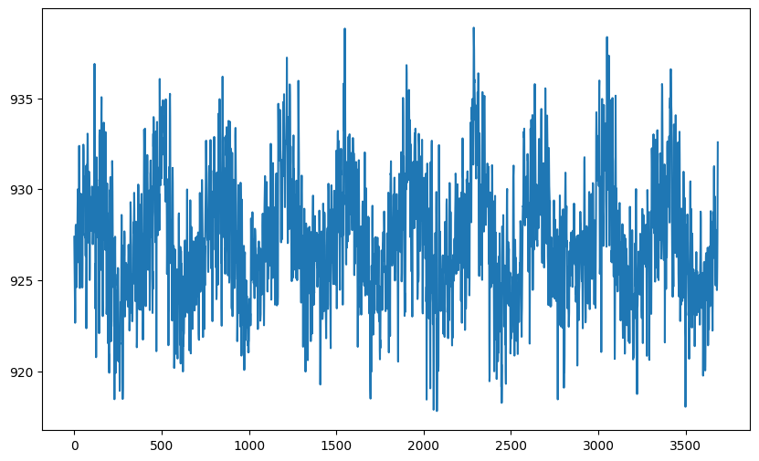

```python
plt.plot(grouped_dates['A701 - pressao atmosferica ao nivel da estacao, horaria (mb)'])
```

Avaliando a pressão atmosférica nessa região paulista, podemos entender que ao longo do tempo a pressão do ar variou em um intervalo relativamente pequeno. Segundo o departamento de fisica da Universidade Federal do Paraná (UFPR) a pressão atmosférica é a altitude e a temperatura. Com isso, podemos interpretar que conforme a temperatura abaixa a pressão atmosférica aumenta e vice-versa. Pois quando as substâncias estão mais frias, as moléculas se fundem e ficam mais densas e por isso a pressão sobe.

- Temperatura do ar em °C

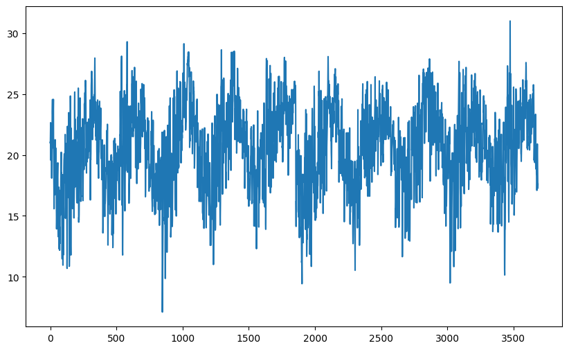

```python
plt.plot(grouped_dates['A701 - temperatura do ar - bulbo seco, horaria (°c)'])
```

Nesse gráfico conseguimos observar uma amplitude térmica elevada e um comportamento cíclio da temperatura no bairro Mirante em São Paulo. A ciclicidade do dados já é esparado dados que o banco possui mais de um ano. E, como já sabemos da região de São Paulo, com verões quentes e invernos gelados, essa amplitude térmica também é esperada.

- Percentual da umidade relativa do ar diária

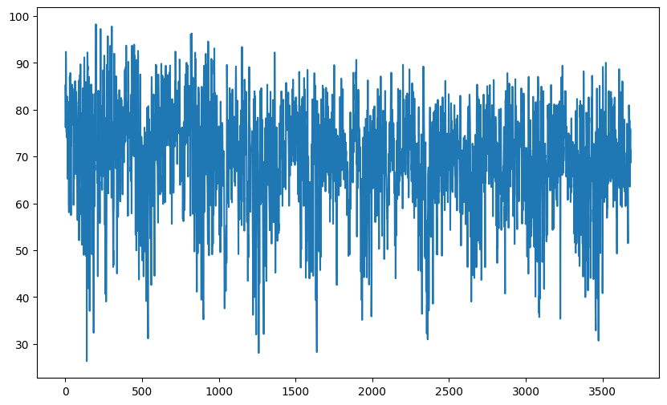

```python
plt.plot(grouped_dates['A701 - umidade relativa do ar, horaria (%)'])
```

Novamente podemos encontrar alguns cíclos onde no verão temos uma umidade maior dado às chuvas e temos invernos mais secos.

- A velocidade média do vento diária em metros por segundo

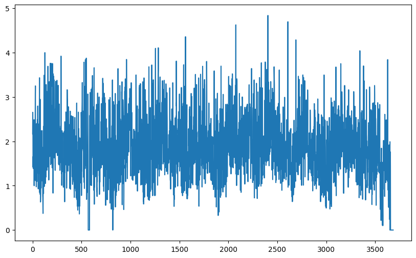

```python
plt.plot(grouped_dates['A701 - vento velocidade horaria (m/s)'])
```

Conforme o gráfico acima houve pouca variação na velocidade do vento ao longo dos dias

# Teste de estacionariedade

Segundo o gráfico acima, temos pouca variação dos dados onde não houve a captura de muitos metros por segundo na estação de Mirante, com máxima de cinco e minima próxima de 0.

Entendido o comportamento das variáveis a serem utilizadas posteriormente no modelo, continuaremos com o estudo. Agora vamos observar se a séries é estacionária pelo teste de dickey-fuller.

Considerando um nível de significância de 95%:

$$ h_0: ρ > 0.05: não-estacionário $$$$ h_1: ρ < 0.05: estacionário $$

```python
def test_stationarity(timeseries):

    print ('Results of Dickey-Fuller Test:')
    dftest = adfuller(timeseries['A701 - temperatura do ar - bulbo seco, horaria (°c)'], autolag='AIC')
    dfoutput = pd.Series(dftest[0:4], index=['Test Statistic','p-value','#Lags Used','Number of Observations Used'])
    for key,value in dftest[4].items():
        dfoutput['Critical Value (%s)'%key] = value
        print (dfoutput)
```

```python
test_stationarity(grouped_dates)
```

```
Results of Dickey-Fuller Test:
Test Statistic                   -5.497674
p-value                           0.000002
#Lags Used                       20.000000
Number of Observations Used    3664.000000
Critical Value (1%)              -3.432136
dtype: float64
Test Statistic                   -5.497674
p-value                           0.000002
#Lags Used                       20.000000
Number of Observations Used    3664.000000
Critical Value (1%)              -3.432136
Critical Value (5%)              -2.862329
dtype: float64
Test Statistic                   -5.497674
p-value                           0.000002
#Lags Used                       20.000000
Number of Observations Used    3664.000000
Critical Value (1%)              -3.432136
Critical Value (5%)              -2.862329
Critical Value (10%)             -2.567190
dtype: float64
```

Considerando que, pelo teste de Dickey-Fuller, a série é estacionária podemos usar vamos plotar as funções de auto-correlação(ACF) e auto-correlação parcial (PACF).

Segundo Hyndman, R. J, ACF significa AutoCorrelation Function é uma medida da dependência linear entre observações consecutivas de uma série temporal. Em outras palavras, o ACF mede o quão fortemente uma observação em um determinado momento está correlacionada com observações em momentos anteriores. Já o PACF significa Partial Autocorrelation Function. É uma medida da dependência linear entre observações consecutivas de uma série temporal, desconsiderando a influência de outras observações intermediárias. Em outras palavras, o PACF mede a correlação entre duas observações deslocadas uma quantidade de períodos, desconsiderando a influência das observações intermediária

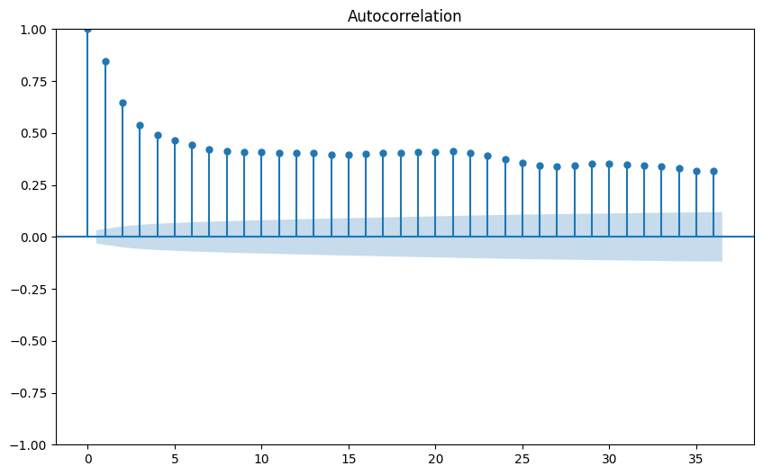

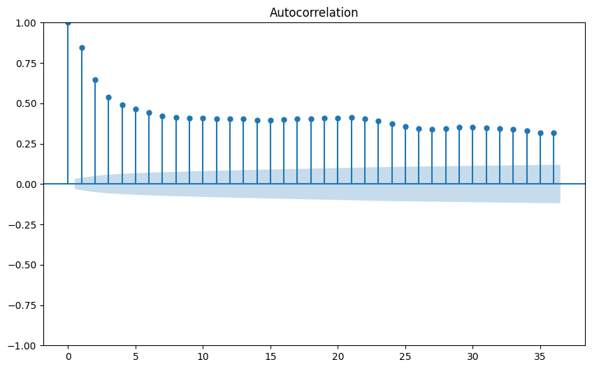

```python
import statsmodels.api as sm
plot_acf(grouped_dates['A701 - temperatura do ar - bulbo seco, horaria (°c)'])
```

Os gráficos ACF não permitem uma interpretação precisa do comportamento das covariáveis no modelo. Para ter uma compreensão mais clara, podemos plotar o PACF, que é o resultado ajustado do ACF. Assim, será possível ter uma visão mais clara do comportamento das variáveis.

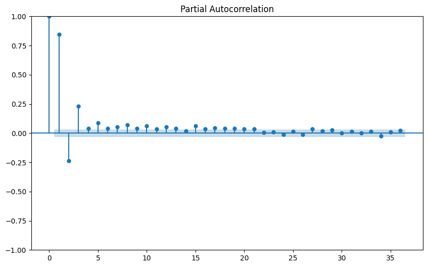

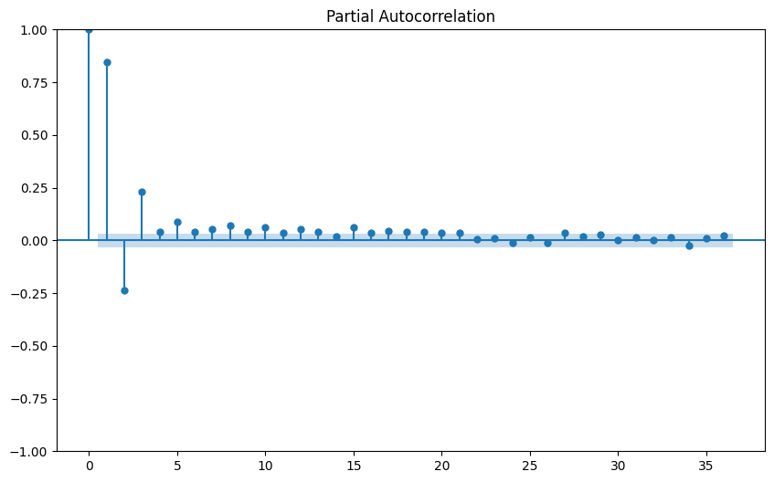

```python
plot_pacf(grouped_dates['A701 - temperatura do ar - bulbo seco, horaria (°c)'])
```

# Cross correlation

De acordo com Hamilton, cross-correlation é uma medida estatística que descreve a relação linear entre duas séries temporais. Ela é usada para medir a associação entre duas variáveis ao longo do tempo, especialmente quando se deseja determinar a existência de uma relação de causalidade entre elas. A cross-correlation pode ser calculada para vários lags diferentes. O valor da função em um determinado lag é a correlação entre as duas séries temporais deslocadas em relação ao tempo em um dado número de períodos (lags).

Se uma das séries influencia a outra, é esperado que a cross-correlação seja positiva para algum lag. Por outro lado, se as séries são independentes, a cross-correlação deve ser próxima de zero para todos os lags.

A cross-correlation é uma ferramenta valiosa para a análise de séries temporais, pois permite a avaliação da relação entre duas séries e pode ser usada para identificar a existência de lags importantes para o modelo.

```python
import statsmodels.api as sm

temperatura = np.array(grouped_dates['A701 - temperatura do ar - bulbo seco, horaria (°c)'])
pressao = np.array(grouped_dates['A701 - pressao atmosferica ao nivel da estacao, horaria (mb)'])
precipitacao = np.array(grouped_dates['A701 - precipitacao total, horario (mm)'])
velocidade_vento = np.array(grouped_dates['A701 - vento velocidade horaria (m/s)'])
umidade = np.array(grouped_dates['A701 - umidade relativa do ar, horaria (%)'])


#calculate cross correlation
cross_correlation_temp_pressao= sm.tsa.stattools.ccf(temperatura, pressao)
cross_correlation_temp_precipitacao = sm.tsa.stattools.ccf(temperatura, precipitacao)
cross_correlation_temp_velocidade_vento = sm.tsa.stattools.ccf(temperatura, velocidade_vento)
cross_correlation_temp_umidade = sm.tsa.stattools.ccf(temperatura, umidade)
```

```python
print(f"Alguns dos pontos da correlação entre temperatura e pressão são: {cross_correlation_temp_pressao}")
print(f"Alguns dos pontos da correlação entre temperatura e precipitação são: {cross_correlation_temp_precipitacao}")
print(f"Alguns dos pontos da correlação entre temperatura e a velocidade do vento são: {cross_correlation_temp_velocidade_vento}")
print(f"Alguns dos pontos da correlação entre temperatura e a umidade são: {cross_correlation_temp_umidade}")
```

```
Alguns dos pontos da correlação entre temperatura e pressão são: [-0.58852768 -0.44382623 -0.30105497 ...  0.20594455  0.09959528
 -0.03155308]
Alguns dos pontos da correlação entre temperatura e precipitação são: [0.05897353 0.02106009 0.04477034 ... 0.28008211 0.31778214 0.27078535]
Alguns dos pontos da correlação entre temperatura e a velocidade do vento são: [-0.14711242 -0.13563664 -0.06568339 ... -0.6259025  -0.68365281
 -0.35968758]
Alguns dos pontos da correlação entre temperatura e a umidade são: [-0.4374982  -0.32379582 -0.16744471 ... -0.73727792 -1.17219472
 -1.27106491]
```

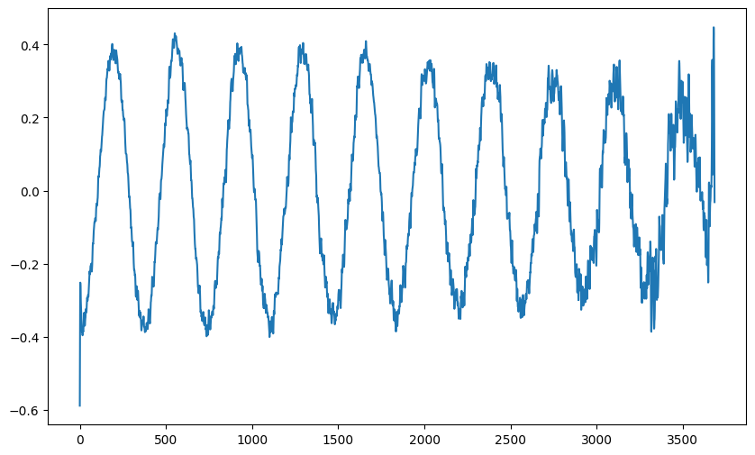

```python
plt.plot(cross_correlation_temp_pressao)
```

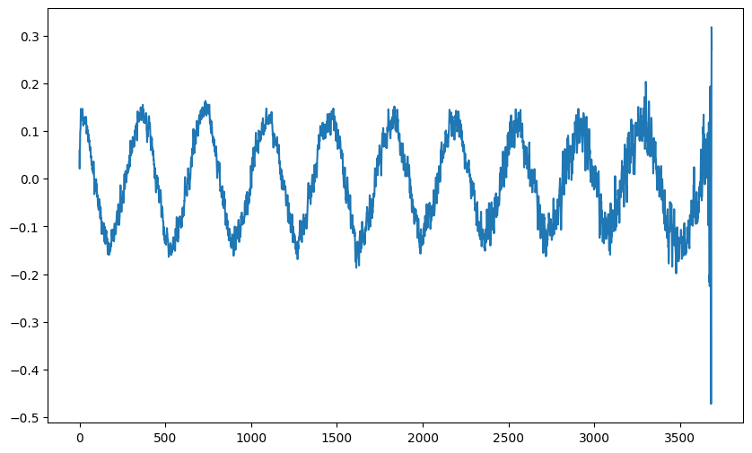

```python
plt.plot(cross_correlation_temp_precipitacao)
```

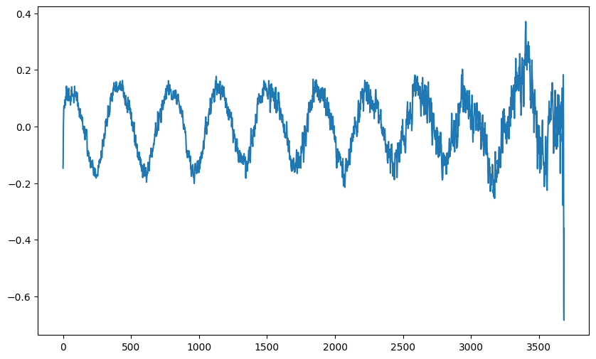

```python
plt.plot(cross_correlation_temp_velocidade_vento)
```

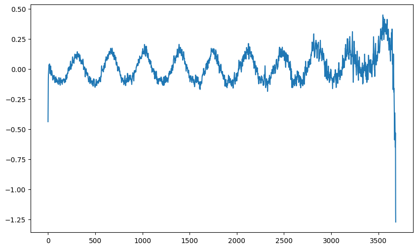

```python
plt.plot(cross_correlation_temp_umidade)
```

# AR

Os modelos AR (autoregressivos) são um tipo de modelo de série temporal que descreve o comportamento de uma variável em função de seus valores passados. A equação básica para um modelo AR de ordem p pode ser escrita como:

$$y_t = c + \phi_1 y_{t-1} + \phi_2 y_{t-2} + ... + \phi_p y_{t-p} + \varepsilon_t$$

- $y_t$ é a variável dependente na observação t
- $c$ é uma constante
- $\phi_1, \phi_2, ..., \phi_p$ são os coeficientes autoregressivos
- $y_{t-1}, y_{t-2}, ..., y_{t-p}$ são as observações anteriores da variável dependente
- $\varepsilon_t$ é o erro na observação t, geralmente assume-se que é um termo de ruído branco (ou seja, uma variável aleatória normalmente distribuída com média zero e variância constante)

O objetivo de ajustar um modelo AR é encontrar os coeficientes φ que melhor descrevem o passado comportamento da série temporal.

# VAR

Segundo Hamilton, o VAR (Vector Autoregression) é um modelo de séries temporais que permite a análise das relações entre duas ou mais variáveis. Este modelo assume que as variáveis são mutuamente dependentes e que mudanças em uma variável afetam as outras.

A ideia por trás do VAR é que cada variável é explicada por suas próprias valores passados de todas as outras variáveis no modelo. Assim, o VAR permite a análise da interação entre as variáveis, a identificação das relações causais e a previsão das futuras observações.

$$ y_t = \alpha + \sum_{i=1}^{p} A_i y_{t-i} + \epsilon_t $$

Em que:

- $y_t$ é a série temporal
- $\alpha$ é o termo de intercepto
- $A_i$ é a matriz de coeficientes para o lag i
- $p$ é o número de lags incluídos na equação
- $\epsilon_t$ é o erro aleatório na previsão no tempo t

A equação representa que a previsão para a série temporal no tempo t ($y_t$) é baseada em sua própria história, sendo influenciada pelos seus valores em lags anteriores ($y_{t-1}$, $y_{t-2}$, etc.), ponderados pelos coeficientes da matriz $A$. Além disso, a equação considera um erro aleatório na previsão ($\epsilon_t$).

```python
grouped_dates = grouped_dates[['dates','A701 - temperatura do ar - bulbo seco, horaria (°c)',
                'A701 - precipitacao total, horario (mm)',
                'A701 - pressao atmosferica ao nivel da estacao, horaria (mb)',
                'A701 - umidade relativa do ar, horaria (%)',
                'A701 - vento velocidade horaria (m/s)']]
```

```python
grouped_dates.iloc[:,3:]
```

|  | A701 - pressao atmosferica ao nivel da estacao, horaria (mb) | A701 - umidade relativa do ar, horaria (%) | A701 - vento velocidade horaria (m/s) |
| --- | --- | --- | --- |
| 0 | 927.383333 | 85.208333 | 2.166667 |
| 1 | 926.345833 | 81.000000 | 2.654167 |
| 2 | 925.804167 | 76.250000 | 2.379167 |
| 3 | 923.729167 | 78.583333 | 2.154167 |
| 4 | 923.795833 | 92.375000 | 1.416667 |
| ... | ... | ... | ... |
| 3680 | 924.845833 | 70.958333 | 0.000000 |
| 3681 | 925.725000 | 75.916667 | 0.000000 |
| 3682 | 927.262500 | 68.625000 | 0.000000 |
| 3683 | 930.837500 | 71.375000 | 0.000000 |
| 3684 | 932.575000 | 69.416667 | 0.000000 |

3685 rows × 3 columns

```python
from statsmodels.tsa.vector_ar.var_model import VAR
vetor1 = np.array(grouped_dates.iloc[:, 1:3])
vetor2 = np.array(grouped_dates.iloc[:,3:])

model = VAR(vetor1, vetor2)
```

```python
modelo_final = model.fit(maxlags = 10)
modelo_final.summary()
```

```
  Summary of Regression Results
==================================
Model:                         VAR
Method:                        OLS
Date:           Mon, 06, Feb, 2023
Time:                     08:49:48
--------------------------------------------------------------------
No. of Equations:         2.00000    BIC:                   -1.12001
Nobs:                     3675.00    HQIC:                  -1.17224
Log likelihood:          -8174.15    FPE:                   0.300859
AIC:                     -1.20111    Det(Omega_mle):        0.296967
--------------------------------------------------------------------
Results for equation y1
=========================================================================
            coefficient       std. error           t-stat            prob
-------------------------------------------------------------------------
const        155.257809         7.961693           19.501           0.000
exog0         -0.154772         0.008454          -18.307           0.000
exog1         -0.091387         0.002393          -38.194           0.000
exog2         -0.397386         0.033828          -11.747           0.000
L1.y1          0.733322         0.015871           46.206           0.000
L1.y2          0.108647         0.055196            1.968           0.049
L2.y1         -0.285608         0.020523          -13.917           0.000
L2.y2          0.040891         0.053827            0.760           0.447
L3.y1          0.158490         0.021069            7.523           0.000
L3.y2          0.089508         0.053596            1.670           0.095
L4.y1          0.002517         0.021258            0.118           0.906
L4.y2          0.089621         0.053432            1.677           0.093
L5.y1          0.048411         0.021234            2.280           0.023
L5.y2          0.111435         0.053407            2.087           0.037
L6.y1          0.021915         0.021230            1.032           0.302
L6.y2          0.086287         0.053364            1.617           0.106
L7.y1          0.002304         0.021215            0.109           0.914
L7.y2          0.199531         0.053304            3.743           0.000
L8.y1          0.039313         0.021037            1.869           0.062
L8.y2          0.232367         0.053320            4.358           0.000
L9.y1         -0.006129         0.020062           -0.305           0.760
L9.y2          0.086228         0.053332            1.617           0.106
L10.y1         0.047991         0.013758            3.488           0.000
L10.y2         0.185445         0.051584            3.595           0.000
```

[output cut: 21 more lines]

```
L6.y2         -0.031187         0.015668           -1.990           0.047
L7.y1          0.003668         0.006229            0.589           0.556
L7.y2          0.016421         0.015651            1.049           0.294
L8.y1          0.002176         0.006177            0.352           0.725
L8.y2          0.000337         0.015655            0.021           0.983
L9.y1         -0.004106         0.005890           -0.697           0.486
L9.y2          0.038573         0.015659            2.463           0.014
L10.y1        -0.001465         0.004040           -0.363           0.717
L10.y2         0.003918         0.015146            0.259           0.796
=========================================================================

Correlation matrix of residuals
            y1        y2
y1    1.000000 -0.093930
y2   -0.093930  1.000000
```

Bibliografia

- Estatística para Dummies, Deborah J. Rumsey
- Site Clima Tempo
- Departamento de física da UFPR
- Fuller, W. A. (1976). Introduction to statistical time series. New York: Wiley.
- Hyndman, R. J., & Athanasopoulos, G. (2018). Forecasting: principles and practice (2nd ed.). OTexts.
- Hamilton, J. D. (1994)